# Homework 5

Fellipe Porto

24/11/2020

```r
# carregando os pacotes

library(dplyr)
library(zoo)
library(lubridate)
```

```r
library(patchwork)
library(coronavirus)
library(ggplot2)
library(ggthemes)
library(extrafont)
# explorando os dados

data("coronavirus")
```

# Estudo de caso sobre os países do BRICS

Há muitos critérios para agrupar países e fazer uma análise, indepedente de qual natureza ela seja. Continente, língua, fronteiras marítimas, etc. Algo que não é tão claro com os países do BRICS, pois não há nada que ligue os cinco países simultaneamente: não são banhados pelos mesmo mares, não são todos do mesmo continente e muito menos existe uma proximidade cultural. Porém é a situção econômica que dá a liga entre eles. O BRICS é um nome designado para os países que tinham uma economia emergente e poderiam se tornar as 5 maiores economias do mundo. O grupo é formado por Brasil, Rússia, Índia, China e África do Sul. Apesar do termo BRICS ser uma categoria acadêmica, ele entrou para o calendário diplomático desses países se tornando ponto de interesse comum e de reconhecimento entre si para negociações econômicas. Contudo, após a pandemia de COVID 19 em 2020, há mais algum fator que aproxime os países do BRICS entre si, além da situação de economias emergentes? É o que tentarei responder com essa atividade. Os dados são do banco de dados The 2019 Novel Coronavirus COVID-19 (2019-nCoV) Dataset, do dia 24/11/2020.

Em um primeiro momento, iremos analisar o número total de casos no mundo e tentar observar algum padrão com a atenção voltada para o BRICS.

```r
# top 30 números de casos

coronavirus %>%
  filter(type == 'confirmed') %>%
  group_by(country) %>%
  summarise(casos_totais = sum(cases)) %>%
  arrange(-casos_totais) %>%
  print(n = 30)
```

```
## # A tibble: 191 x 2
##    country        casos_totais
##    <chr>                 <int>
##  1 US                 12246849
##  2 India               9139865
##  3 Brazil              6071401
##  4 France              2191180
##  5 Russia              2071858
##  6 Spain               1556730
##  7 United Kingdom      1515802
##  8 Italy               1408868
##  9 Argentina           1370366
## 10 Colombia            1248417
## 11 Mexico              1041875
## 12 Peru                 948081
```

[output cut: 19 more lines]

```r
# casos na China

coronavirus %>%
  filter(type == 'confirmed', country == 'China') %>%
  summarise(total_cases = sum(cases))
```

```
##   total_cases
## 1       92116
```

Como é possível observar, Índia, Brasil e Rússia ocupam, respectivamente, segundo, terceiro e quinto lugar no número de casos totais. Isso são três dos cinco países dos BRICS que estão no top 5 países com maior número total de casos. Africa do Sul ocupa a #16 posição e a China, apesar de ser o foco inicial do COVID 19, nem mesmo aparece no top 30, possuindo um total de 92.116 casos.

Agora vamos observar a evolução dos casos confirmados de COVID 19 nos países que fazem parte do BRICS.

```r
#### filtrando os dados apenas para os países do brics
brics_cases <- coronavirus %>%
  filter(country %in% c('Brazil',
                        'Russia',
                        'India',
                        'South Africa'),
         type == 'confirmed')%>%
  select(date, country, type, cases) %>%
  tibble::as.tibble()
china_casos <- coronavirus %>%
  filter(country %in% c('China'), type == 'confirmed')%>%
  select(date, country, type, cases)%>%
  group_by(date)%>%
  mutate(tot_cases = sum(cases)) %>%
  select(-cases) %>%
  distinct()%>%
  rename(cases = tot_cases) %>%
  tbl_df()
```

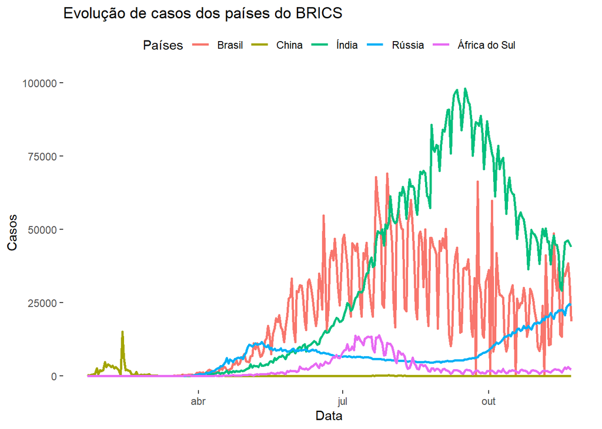

```r
brics_cases <- brics_cases %>% rbind(china_casos)



#### plotando

brics_cases %>%
  ggplot(aes(x = date, y = cases, col = country))+
  geom_line(size = 1)+
  scale_color_discrete(name = 'Países', labels = c('Brasil',
                                                   'China',
                                                   'Índia',
                                                   'Rússia',
                                                   'África do Sul'))+
  theme_tufte()+
  theme(text = element_text(family = 'Rubik'),
        legend.position = 'top')+
  labs(title = 'Evolução de casos dos países do BRICS',
       x = 'Data',
       y = 'Casos')
```

É possível observar que logo após abril, todos os países analisados, com exceção da China, sofreram uma alta nos casos, com o Brasil possuindo o maior número de casos, mas sendo, posteriormente, ultrapassado pela Índia, que teve um grande aumento de casos após Julho, superando o Brasil nos meses seguinte, e sendo, atualmente, o país com mais casos.

O gráfico seguinte trata da evolução do número de mortes em cada país.

[output not shown]

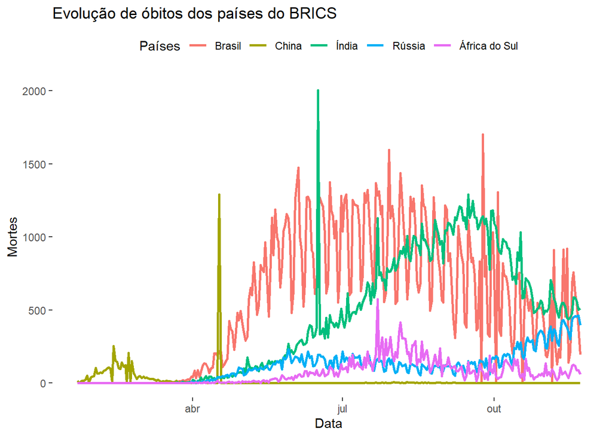

```r
## numero de óbitos

## numero de óbitos

brics_deaths <- coronavirus %>%
  filter(country %in% c('Brazil',
                        'Russia',
                        'India',
                        'South Africa'),
         type == 'death')%>%
  select(date, country, type, cases) %>%
  tibble::as.tibble()

china_mortes <- coronavirus %>%
  filter(country %in% c('China'), type == 'death')%>%
  select(date, country, type, cases)%>%
  group_by(date)%>%
  mutate(tot_cases = sum(cases)) %>%
  select(-cases) %>%
  distinct()%>%
  rename(cases = tot_cases) %>%
  tbl_df()

brics_deaths <- brics_deaths %>% rbind(china_mortes) %>%
  mutate(casos_acumulados = cumsum(cases))

#### plotando

brics_deaths %>%
  ggplot(aes(x = date, y = cases, col = country))+
  geom_line(size = 1)+
  scale_color_discrete(name = 'Países', labels = c('Brasil',
                                                   'China',
                                                   'Índia',
                                                   'Rússia',
                                                   'África do Sul'))+
  theme_tufte()+
  theme(text = element_text(family = 'Rubik'),
        legend.position = 'top')+
  labs(title = 'Evolução de óbitos dos países do BRICS',
       x = 'Data',
       y = 'Mortes')
```

Para minimizar as diferenças diárias, o próximo gráfico tratará da média móvel de morte em cada país.

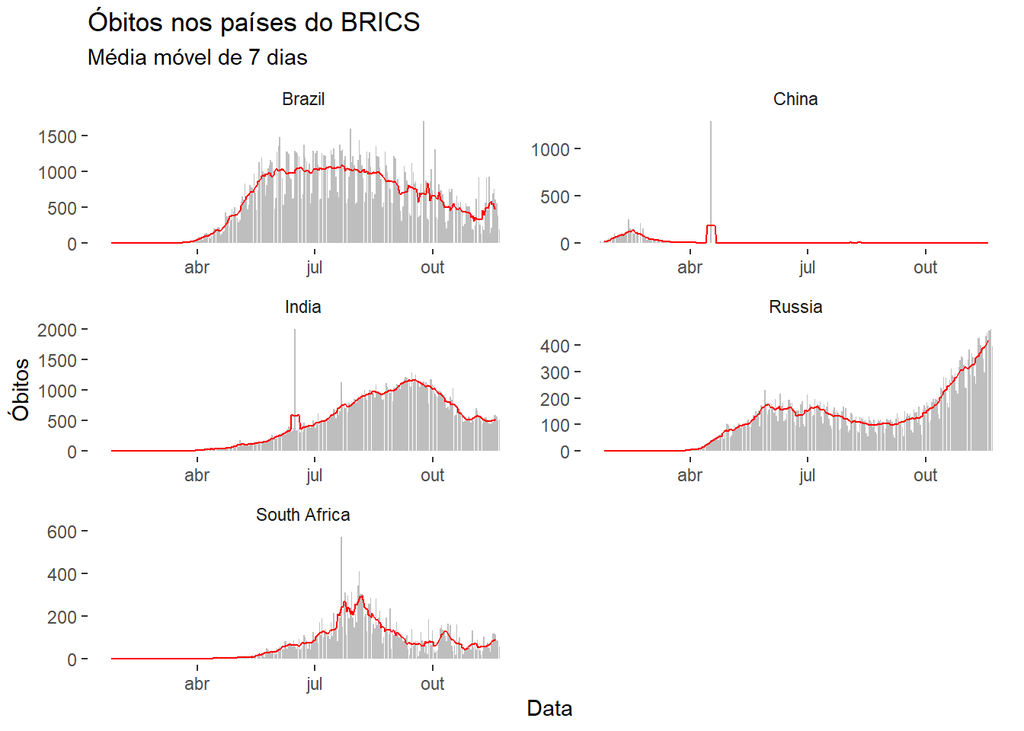

```r
## média móvel por pais

brics_deaths %>%
  group_by(country) %>%
  mutate(mediaMovel = zoo::rollmean(cases, k = 7, fill = NA))%>%
  tbl_df()%>%
  ggplot(aes(x=date)) +
  geom_bar(aes(y = cases), stat = "identity", fill = "grey") +
  geom_line(mapping=aes(x = date, y = mediaMovel), color="red")+
  facet_wrap(~country, ncol = 2, scales = 'free')+
  theme_tufte()+
  theme(text = element_text(family = 'Rubik'))+
  labs(title = "Óbitos nos países do BRICS",
       subtitle = 'Média móvel de 7 dias',
       y = "Óbitos",
       x = "Data")
```

```r
# total de mortes em cada país

total_br <-  coronavirus %>%
  filter(country == 'Brazil', type == 'death') %>%
  group_by(country) %>%
  summarise(total = sum(cases)) %>%
  as.data.frame(t(total_br))
total_chi <-  coronavirus %>%
  filter(country == 'China', type == 'death') %>%
  group_by(country) %>%
  summarise(total = sum(cases)) %>%
  as.data.frame(t(total_chi))
total_ru <-  coronavirus %>%
  filter(country == 'Russia', type == 'death') %>%
  group_by(country) %>%
  summarise(total = sum(cases))
total_af <-  coronavirus %>%
  filter(country == 'South Africa', type == 'death') %>%
  group_by(country) %>%
  summarise(total = sum(cases))
total_in <-  coronavirus %>%
  filter(country == 'India', type == 'death') %>%
  group_by(country) %>%
  summarise(total = sum(cases))
totalMortes <- print(c(total_br, total_in, total_ru, total_in, total_chi))
```

```
## $country
## [1] "Brazil"
##
## $total
## [1] 169183
##
## $country
## [1] "India"
##
## $total
## [1] 133738
##
## $country
## [1] "Russia"
##
## $total
## [1] 35838
##
## $country
## [1] "India"
##
## $total
## [1] 133738
##
## $country
## [1] "China"
##
## $total
## [1] 4742
```

Com o objetivo de entender os óbitos de maneira mais apropriada, os códigos a seguir irão tratar os dados com o objetivo de chegar às mortes por milhão de habitantes, métrica mais precisa, pois ignora a divergência de habitantes que existe entre cada país. As informações à respeito da população de cada país pode ser acessada [aqui](https://pt.wikipedia.org/wiki/BRICS).

```r
# mortes por milhao em cada pais do brics


## mortes por milhão

hab_br <- 215967714
hab_in <- 1180251000
hab_chi <- 1338612968
hab_af <- 49320500
hab_ru <- 141927297

mMilhao_br <- (total_br[,2]/hab_br)*1000000
mMilhao_in <- (total_in[,2]/hab_in)*1000000
mMilhao_chi <- (total_chi[,2]/hab_chi)*1000000
mMilhao_af <- (total_af[,2]/hab_af)*1000000
mMilhao_ru <- (total_ru[,2]/hab_ru)*1000000


#### plotando

mMilhao_brics <- as.data.frame(c(mMilhao_br, mMilhao_af, mMilhao_ru, mMilhao_in, mMilhao_chi))

mMilhao_brics <- mMilhao_brics %>%
  rename(Brasil = X783.371721941734,
         AfricadoSul  = total,
         Russia =  total.1,
         India = total.2,
         China = X3.54247277843494)

rownames(mMilhao_brics) <- 'Mortes por Milhão'

mMilhao_brics
```

```
##                     Brasil AfricadoSul   Russia    India    China
## Mortes por Milhão 783.3717    423.8197 252.5096 113.3132 3.542473
```

O Brasil é disparado o país com mais mortes por milhão de habitantes, seguido de África do Sul e Rússia. A china, tem a menor taxa de mortos por milhão dos BRICS.

Entre os países do BRICS, apenas a China não teve uma explosão de casos e mortes, e, mesmo sendo o país inicial do COVID 19, soube controlar muito bem a pandemia. Os demais países já não conseguiram ter sucesso. Todos os demais países tiveram muitas mortes e muitos casos, sendo que Brasil e Índia conseguem ter números altos para as duas categorias.